# Test_a_Perceptual_Phenomenon

### Analyzing the Stroop Effect

Perform the analysis in the space below. Remember to follow [the instructions](https://docs.google.com/document/d/1-OkpZLjG_kX9J6LIQ5IltsqMzVWjh36QpnP2RYpVdPU/pub?embedded=True) and review the [project rubric](https://review.udacity.com/#!/rubrics/71/view) before submitting. Once you've completed the analysis and write-up, download this file as a PDF or HTML file, upload that PDF/HTML into the workspace here (click on the orange Jupyter icon in the upper left then Upload), then use the Submit Project button at the bottom of this page. This will create a zip file containing both this .ipynb doc and the PDF/HTML doc that will be submitted for your project.

(1) What is the independent variable? What is the dependent variable?

**Independent variable is the congruency of the colour and text. For the dependent variable, Duration (time) to recognise the colours or the texts**

(2) What is an appropriate set of hypotheses for this task? Specify your null and alternative hypotheses, and clearly define any notation used. Justify your choices.

**We assume that the time taken to read Incongruent words is less or equal to the time taken to read Congruent words.We are interested in proving that the time taken to read the Incongruent words is more than the time taken to read Congruent word.**

**So our null and alternative hypothesis in terms of** $\mu_{cong}$ **and** $\mu_{Incong}$ **which are population mean values for time taken to read Congruent and Incongruent words.**

**$$H_0: \mu_{Incong} - \mu_{cong} \leq 0$$**

**$$H_1: \mu_{Incong} - \mu_{cong} > 0$$**

(3) Report some descriptive statistics regarding this dataset. Include at least one measure of central tendency and at least one measure of variability. The name of the data file is 'stroopdata.csv'.

```python
# Perform the analysis here
import pandas as pd
import numpy as np
import random
import matplotlib.pyplot as plt
%matplotlib inline
random.seed(42)
```

```python
# read data from the file
data = pd.read_csv('stroopdata.csv')
data.head()
```

|  | Congruent | Incongruent |
| --- | --- | --- |
| 0 | 12.079 | 19.278 |
| 1 | 16.791 | 18.741 |
| 2 | 9.564 | 21.214 |
| 3 | 8.630 | 15.687 |
| 4 | 14.669 | 22.803 |

```python
data.shape
```

```
(24, 2)
```

```python
# calculate population mean time for Congruent words
mean_cong = data['Congruent'].mean()
mean_cong
```

```
14.051124999999999
```

```python
# calculate population mean time for Incongruent words
mean_incong = data['Incongruent'].mean()
mean_incong
```

```
22.015916666666666
```

**Population mean for the time taken to read Congruent words is 14.0511 Population mean for the time taken to read Incongruent words is 22.0159**

**Calculate Five Number summary for Congruent words.**

```python
# Calculate min value for Congruent words
min_cong = data['Congruent'].min()
min_cong
```

```
8.6300000000000008
```

```python
# Q1
np.percentile(data['Congruent'],25)
```

```
11.895250000000001
```

```python
# calculate median for Congruent words
# Q2
median_cong = data['Congruent'].median()
median_cong
```

```
14.3565
```

```python
# Q3
np.percentile(data['Congruent'],75)
```

```
16.200749999999999
```

```python
# Calculate max value for Congruent words
max_cong = data['Congruent'].max()
max_cong
```

```
22.328000000000003
```

```python
# IQR for Congruent words
np.percentile(data['Congruent'],75) - np.percentile(data['Congruent'],25)
```

```
4.3054999999999986
```

```python
# Population standard deviation for Congruent words
data['Congruent'].std(ddof=0)
```

```
3.4844157127666331
```

**Below is the summary of measures for the Congruent words is as follows**

**The smallest number in the dataset , Min = 8.63**

**The value such that 25% of the data fall below, Q1 = 11.895**

**The value such that 75% of the data fall below, Q3 = 16.2007**

**The largest value in the dataset, Maximum = 22.328**

**Inter Quartile Range = 4.30549**

**Standard Deviation = 3.4844**

**Calculate Five number summery for Incongruent words.**

```python
# Calculate min value for Congruent words
min_incong = data['Incongruent'].min()
min_incong
```

```
15.687000000000001
```

```python
# Q1
np.percentile(data['Incongruent'],25)
```

```
18.716750000000001
```

```python
# calculate median for Congruent words
# Q2
median_incong = data['Incongruent'].median()
median_incong
```

```
21.0175
```

```python
# Q3
np.percentile(data['Incongruent'],75)
```

```
24.051500000000001
```

```python
# Calculate max value for Incongruent words
max_incong = data['Incongruent'].max()
max_incong
```

```
35.255000000000003
```

```python
# IQR for Incongruent words
np.percentile(data['Incongruent'],75) - np.percentile(data['Incongruent'],25)
```

```
5.3347499999999997
```

```python
# Population standard deviation for Incongruent words
data['Incongruent'].std(ddof=0)
```

```
4.6960551345133172
```

**The smallest number in the dataset , Min = 15.687**

**The value such that 25% of the data fall below, Q1 = 18.716**

**The value such that 50% of the data fall below, Q2 = 21.0175**

**The value such that 75% of the data fall below, Q3 = 24.0515**

**The largest value in the dataset, Maximum = 35.255**

**Inter Quartile Range = 5.334**

**Standard Deviation = 4.696**

(4) Provide one or two visualizations that show the distribution of the sample data. Write one or two sentences noting what you observe about the plot or plots.

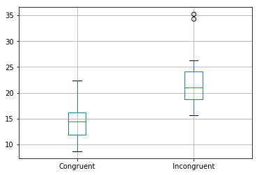

```python
# Build the visualizations here
# Create a box blot to compare the spread of the data for Congruent and Incongruent words
data.boxplot();
```

```python
# store the data frame index into a list
y=list(range(len(data.index)))
```

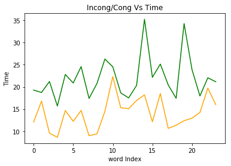

```python
# plot the time taken to read the words
plt.plot(y,data['Incongruent'],color='green')
plt.plot(y,data['Congruent'],color='orange')
plt.title('Incong/Cong Vs Time')
plt.xlabel('word Index')
plt.ylabel('Time');
```

**Based on the above plot we can see that time taken to read Incongruent is more than the time taken to read Congruent words**

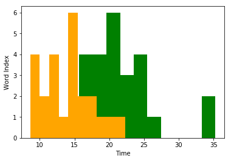

```python
# Plot a histogram of the data sets for Incongruent and Congruent
plt.hist(data['Incongruent'],color='green');
plt.hist(data['Congruent'],color='orange');
plt.xlabel('Time')
plt.ylabel('Word Index');
```

(5) Now, perform the statistical test and report your results. What is your confidence level or Type I error associated with your test? What is your conclusion regarding the hypotheses you set up? Did the results match up with your expectations? **Hint:** Think about what is being measured on each individual, and what statistic best captures how an individual reacts in each environment.

```python
# Perform the statistical test here
# Compute the obsolute difference in the popualation means
# for the time taken to read congruent and incongruent words
obs_diff = mean_incong - mean_cong

# display observed difference
obs_diff
```

```
7.9647916666666667
```

```python
# create sampling distribution of difference in means for the time taken to read
# congruent and incongruent words
# using bootstrapping
diffs = []
# size = df2.shape[0]
for _ in range(10000):
    b_samp = data.sample(24, replace=True)
    mean_incong = b_samp['Incongruent'].mean()
    mean_cong = b_samp['Congruent'].mean()
    diffs.append(mean_incong - mean_cong)

# convert to numpy array
diffs = np.array(diffs)
```

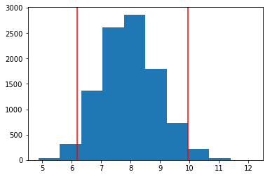

```python
# lower and upper bounds to build 95% confidence interval
lower , upper  = np.percentile(diffs,2.5) , np.percentile(diffs,97.5)
# plot sampling distribution
plt.hist(diffs);
plt.axvline(x=lower, color='red');
plt.axvline(x=upper, color='red');
```

**Above is the sampling distribution of the difference in means for the time taken to read congruent and incongruent words.We plotted the lower and upper bounds with 95% confidence interval.Observed statistic is 7.96479,which suggests that average time taken to read Incongruent words is more than the average time taken to read Congruent words i.e $$H_1: \mu_{Incong} - \mu_{cong} > 0$$ . This is also backed by the sampling distribution of difference in means generated by bootstrapping. All the values in the confidence interval are greater than 0. This plot shows sufficient evidence to reject the null hypothesis**

```python
# simulate distribution under the null hypothesis
null_vals = np.random.normal(0, diffs.std(), diffs.size)
```

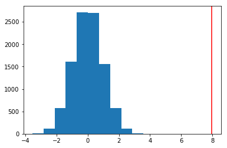

```python
# plot null distribution
plt.hist(null_vals);

# plot line for observed statistic
plt.axvline(obs_diff, c='red');
```

```python
# compute p value
(null_vals > obs_diff).mean()
```

```
0.0
```

**We would expect the sampling distribution to be normal by the Central Limit Theorem, and we know the standard deviation of the sampling distribution of the difference in means the we generated by bootstrapping.We can use this to simulate draws from the sampling distribution under the null hypothesis.If there is no difference, then the difference between the means should be zero.**

**p_val is the probability of obtaining the obersed statistic or a more extrement value if the null hypothesis is true.In our case the obeserved statistic is 7.96479. Plotting this on the sampling distribution of difference in means generated under the null hypothesis shows the area on the distribution that falls to the right of the observed statistic. In this case p value is 0.0, so 0% of the values in the null hypothesis fall above the observed statistic. Considering Type-1 error rate in this case as 5%.$$p = 0.0$$$$\alpha = 0.05$$p-val is way below this so there is substantial evidence to reject the null hypothesis. On average people take more time to read Incongruent words than Congruent words**

(6) Optional: What do you think is responsible for the effects observed? Can you think of an alternative or similar task that would result in a similar effect? Some research about the problem will be helpful for thinking about these two questions!

**There are two theories that may explain the Stroop effect:**

**Speed of Processing Theory: the interference occurs because words are read faster than colors are named. Selective Attention Theory: the interference occurs because naming colors requires more attention than reading words.**

**For more information on this test ,please refer to [this link](https://en.wikipedia.org/wiki/Stroop_effect)**